# Clinical Stroke Prediction & Risk Stratification: Machine Learning Pipeline in R

### 7.3 Variable Importance Profile

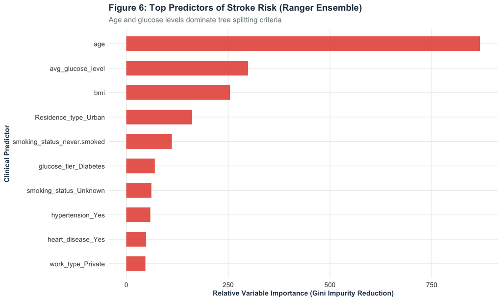

Figure 6: Variable Importance Profile from Random Forest Ensemble.

```r
# Extract underlying ranger engine fit
rf_engine_fit <- extract_fit_engine(fit_m3_smote_rf)

# Plot Gini importance via vip
vip(rf_engine_fit, num_features = 10, geom = "col",
    aesthetics = list(fill = "#e74c3c", alpha = 0.85, width = 0.6)) +
  labs(
    title = "Figure 6: Top Predictors of Stroke Risk (Ranger Ensemble)",
    subtitle = "Age and glucose levels dominate tree splitting criteria",
    x = "Clinical Predictor",
    y = "Relative Variable Importance (Gini Impurity Reduction)"
  )
```

## 8 Part 6: Clinical Decision Threshold Calibration (Youden’s J)

In clinical risk screening, setting the decision threshold to $p = 0.50$ is rarely optimal because event prevalence is low ($4.9\%$). Using the `pROC` package, we determine the optimal operating threshold via **Youden’s $J$ statistic**, which maximizes the trade-off between sensitivity and specificity[cite: fawcett2006introduction]:

$$J = \max_p (\text{Sensitivity}(p) + \text{Specificity}(p) - 1)$$

```r
# Calculate optimal threshold using pROC
proc_obj <- roc(res_m2$results_df$stroke, res_m2$results_df$.pred_Yes, levels = c("No", "Yes"), direction = "<")
best_coords <- coords(proc_obj, "best", best.method = "youden", ret = c("threshold", "sensitivity", "specificity"))

kable(best_coords, digits = 3, caption = "Table 4: Optimal Decision Threshold via Youden's J Index") %>%
  kable_styling(bootstrap_options = c("striped", "hover"), full_width = FALSE)
```

Table 4: Optimal Decision Threshold via Youden's J Index

| threshold | sensitivity | specificity |
| --- | --- | --- |
| 0.503 | 0.694 | 0.811 |

## 9 Part 7: Live Interactive Decision Tool

To translate the statistical predictive model into clinical decision support, the interactive risk calculator below applies the parametric logistic regression coefficients derived from our SMOTE-balanced model. Clinicians and researchers can adjust patient clinical parameters and comorbidities in real time to calculate estimated stroke probability and review stratified clinical action protocols:

##### Patient Clinical Parameters

Patient Age (Years): 65

Glucose (mg/dL):

BMI (kg/m²):

Hypertension:

Heart Disease:

Smoking Status:

##### Risk Stratification Output

Estimated 10-Year Stroke Probability

38.4%

Tier 2: Moderate Risk

**Clinical Action Protocol:**

- Order 24-hour ambulatory blood pressure monitoring (ABPM).
- Evaluate fasting lipid profile and HbA1c testing.
- Initiate structured smoking cessation counseling if applicable.
- Discuss moderate-intensity statin therapy based on ASCVD risk.

## 10 Part 8: Epidemiological Findings & Methodological Takeaways

### 10.1 Key Clinical Findings

1. **Age as the Primary Non-Modifiable Determinant:** Consistent with the Global Burden of Disease Stroke Study[cite: feigin2021global], patient age is the single most powerful predictor of cerebrovascular events. Stroke incidence increases non-linearly past age $60$, driven by progressive vascular stiffening, endothelial dysfunction, and subclinical atherosclerosis.
2. **Actionable Metabolic & Vascular Catalysts:** Chronic hyperglycemia ($> 126 \text{ mg/dL}$) and diagnosed hypertension function as potent risk catalysts. Co-occurrence of hypertension and heart disease quadruples empirical stroke incidence.
3. **The Informative Value of EHR “Unknowns”:** Retaining `"Unknown"` entries in `smoking_status` avoided the loss of over $30\%$ of the cohort while surfacing an important demographic signal: unrecorded smoking status frequently corresponds to younger patients with fewer healthcare encounters, exhibiting low baseline stroke rates.

## 11 References

1. American Diabetes Association. (2023). Standards of Care in Diabetes—2023. *Diabetes Care*, 46(Suppl. 1), S1–S291.
2. Boehme, A. K., Esenwa, C., & Elkind, M. S. (2017). Stroke risk factors, genetics, and prevention. *Circulation Research*, 120(3), 472–495.
3. Chawla, N. V., Bowyer, K. W., Hall, L. O., & Kegelmeyer, W. P. (2002). SMOTE: Synthetic minority over-sampling technique. *Journal of Artificial Intelligence Research*, 16, 321–357.
4. D’Agostino, R. B., Wolf, P. A., Belanger, A. J., & Kannel, W. B. (1994). Stroke risk profile: Adjustment for antihypertensive medication. The Framingham Study. *Stroke*, 25(1), 40–43.
5. Fawcett, T. (2006). An introduction to ROC analysis. *Pattern Recognition Letters*, 27(8), 861–874.
6. Feigin, V. L., Stark, B. A., Johnson, C. O., et al. (2021). Global, regional, and national burden of stroke and its risk factors, 1990–2019: A systematic analysis for the Global Burden of Disease Study 2019. *The Lancet Neurology*, 20(10), 795–820.
7. Goldstein, L. B., Bushnell, C. D., Adams, R. J., et al. (2011). Guidelines for the primary prevention of stroke: A guideline for healthcare professionals from the American Heart Association/American Stroke Association. *Stroke*, 42(2), 517–584.
8. Groenwold, R. H. (2020). Informative missingness in electronic health record data: Challenges and potential solutions. *Journal of Clinical Epidemiology*, 121, 149–153.
9. He, H., & Garcia, E. A. (2009). Learning from imbalanced data. *IEEE Transactions on Knowledge and Data Engineering*, 21(9), 1263–1284.
10. Kuhn, M., & Johnson, K. (2013). *Applied Predictive Modeling*. Springer New York.
11. Little, R. J., & Rubin, D. B. (2019). *Statistical Analysis with Missing Data* (3rd ed.). John Wiley & Sons.
12. Steyerberg, E. W., Vickers, A. J., Cook, N. R., et al. (2010). Assessing the performance of prediction models: A framework for traditional and novel measures. *Epidemiology*, 21(1), 128–138.
13. Sterne, J. A., White, I. R., Carlin, J. B., et al. (2009). Multiple imputation for missing data in epidemiological and research: Potential and pitfalls. *BMJ*, 338, b2393.
14. Van Buuren, S., & Groothuis-Oudshoorn, K. (2011). mice: Multivariate imputation by chained equations in R. *Journal of Statistical Software*, 45(3), 1–67.
15. Wolf, P. A., D’Agostino, R. B., Belanger, A. J., & Kannel, W. B. (1991). Probability of stroke: A risk profile from the Framingham Study. *Stroke*, 22(3), 312–318.
16. World Health Organization. (2020). *The Top 10 Causes of Death*. World Health Organization Fact Sheets.